# LittleCoders

D.M.K.M.Dissanayake

2024-08-10

# Dataset

```
## # A tibble: 17 × 7
##    `Course name`   `Age Group` Features Duration `Registration fee` `Course fee`
##    <chr>           <chr>       <chr>    <chr>    <chr>              <chr>
##  1 CODEJUNIORS     9-12        "Scratc… 192 hou… 10000              304000
##  2 CODEMASTERS     13-16       "Python… 192 hou… 10000              304000
##  3 Artificial Int… 10-16       "Artifi… 24 hours 10000              38000
##  4 Learning path … 11-13       "Scratc… 50 hours NA                 50000
##  5 Knowledge Expl… 9-13        "Scratc… 50 hours NA                 50000
##  6 Specialise in … 14-16       "Scratc… 50 hours NA                 50000
##  7 Certificate of… 10-17       "Python… 32 hours NA                 27000
##  8 Certificate Of… 10-17       "HTML/C… 22 hours NA                 27000
##  9 Computer Progr… 8-15        "Scratc… 24 hours NA                 12000
## 10 Slasscom Techk… 10-16       "Scratc… -        NA                 NA
## 11 Coding for kids 8-16        "Scratc… 60 hours 5000               60000
## 12 Code Creators:… 6-14        "Comput… 30 hours NA                 60000
## 13 App Design & D… 10+         "App De… 30 hours NA                 60000
## 14 App Design & D… 10+         "App De… 20 hours NA                 60000
## 15 Python Course … 12+         "Python… 30 hours NA                 60000
## 16 AI & Machine L… 12+         "Python… 20 hours NA                 60000
## 17 Web Design & D… 10+         "Web De… 30 hours NA                 60000
## # ℹ 1 more variable: `Delivery method` <chr>
```

## Structure of the dataset

```
## tibble [17 × 7] (S3: tbl_df/tbl/data.frame)
##  $ Course name     : chr [1:17] "CODEJUNIORS" "CODEMASTERS" "Artificial Intelligence" "Learning path - For the Analyst" ...
##  $ Age Group       : chr [1:17] "9-12" "13-16" "10-16" "11-13" ...
##  $ Features        : chr [1:17] "Scratch, Mobile App Development, Python, Web Development, HTML/CSS, JavaScript" "Python, Web Development, HTML/CSS, JavaScript, PHP, MySQL" "Artificial Intelligence, Machine Learning, Scratch, PictoBlox, Computer Vision, Face Recognition, Optical Chara"| __truncat…
##  $ Duration        : num [1:17] 192 192 24 50 50 50 32 22 24 NA ...
##  $ Registration fee: num [1:17] 10000 10000 10000 NA NA NA NA NA NA NA ...
##  $ Course fee      : num [1:17] 304000 304000 38000 50000 50000 50000 27000 27000 12000 NA ...
##  $ Delivery method : Factor w/ 2 levels "Hybrid","Online": 1 1 1 1 1 1 2 2 1 2 ...
```

## 1. Demographic Insight

To Analyze the target demographics for each course to understand the primary audience.

#### Summary statistics for minimum age

```
##    Min. 1st Qu.  Median    Mean 3rd Qu.    Max.
##    6.00    9.00   10.00   10.12   11.00   14.00
```

#### Summary statistics for maximum age

```
##    Min. 1st Qu.  Median    Mean 3rd Qu.    Max.
##      12      15      16     Inf     Inf     Inf
```

#### Age Distribution of Coding Courses

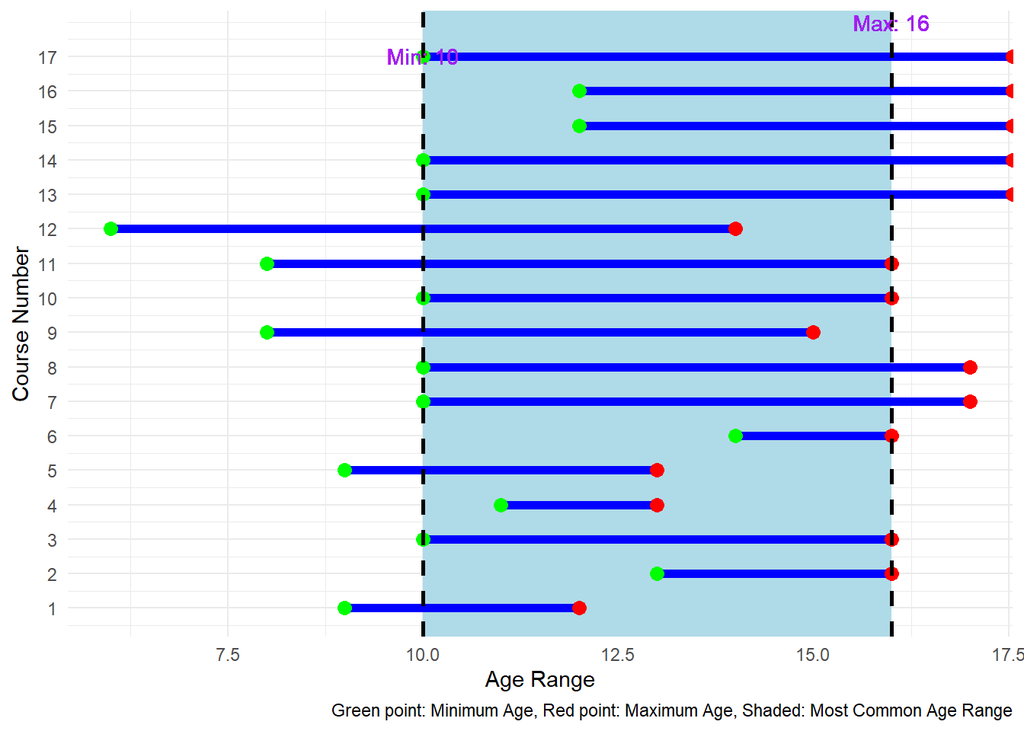

Here the most courses are designed for children between 10 and 16 years old. This indicates that the primary audience for these coding courses is pre-teens and teenagers.

## 2. Curriculum & Feature Insight

To understand which coding languages and topics are most commonly taught and identify the unique features of each course.

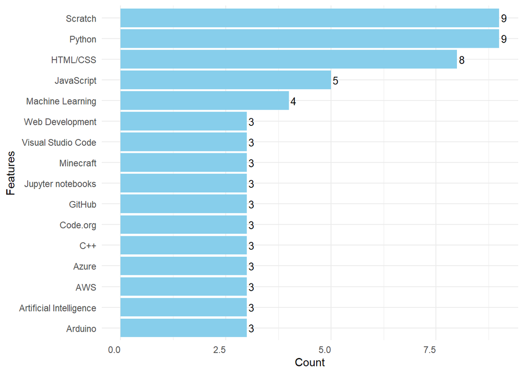

#### The unique features

```
## # A tibble: 55 × 2
##    Features                    n
##    <chr>                   <int>
##  1 AI                          1
##  2 Academia                    1
##  3 Animation                   1
##  4 App Design                  1
##  5 App Inventor                1
##  6 Astronomy                   1
##  7 Basic Electronics           1
##  8 Bioinformatics              1
##  9 Build responsive Layout     1
## 10 CSS Transition              1
## # ℹ 45 more rows
```

The most commonly taught topics across coding courses in Sri Lanka for 11-16-year-olds are Python, Scratch, and HTML/CSS. These languages and tools appear frequently, indicating a strong focus on foundational programming and web development skills.

Additionally, there are unique features, such as AI, App Design, and App Development, which are only offered in one course each, highlighting specialized areas not commonly covered in other programs.

## 3. Pricing Insight

To analyze the cost structure of coding courses, including registration fees, monthly fees, and total costs.

#### Distribution of Registration Fees

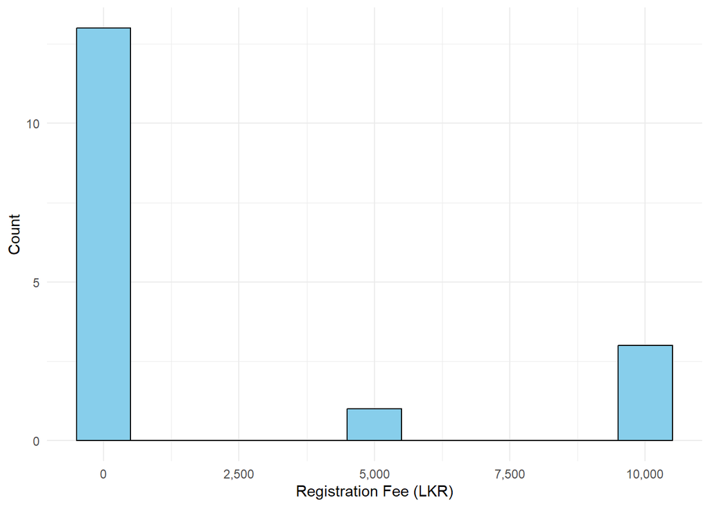

#### Distribution of Course Fees

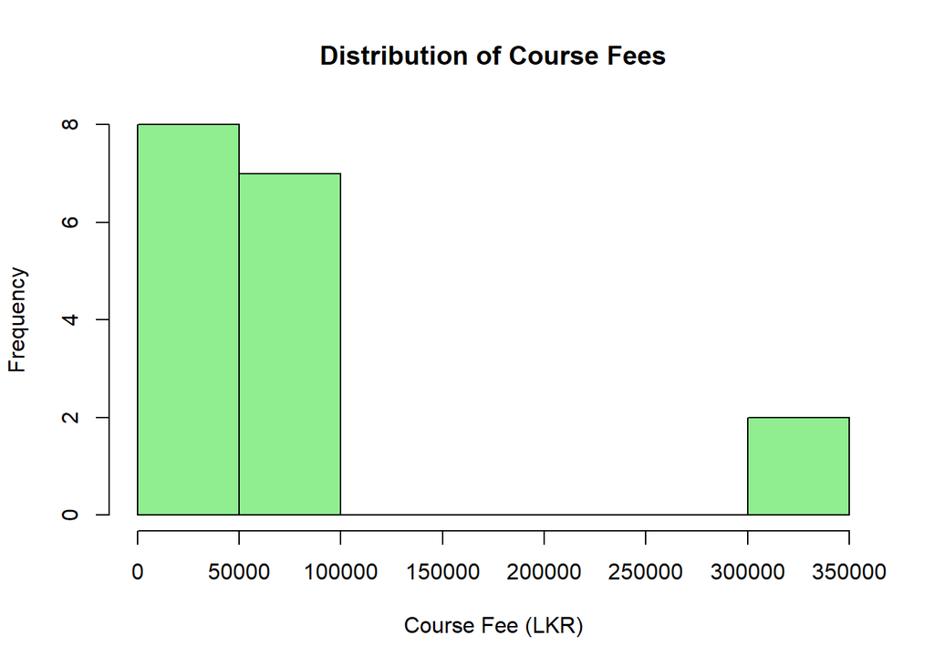

#### Summary Statistics for Registration and Course Fees

Summary Statistics for Registration and Course Fees (excluding zeros)

| Statistic | Registration_Fees | Course_Fees |
| --- | --- | --- |
| Max | 10000 | 304000 |
| Min | 5000 | 12000 |
| Common Range (25th-75th Percentile) | 8750 - 10000 | 47000 - 60000 |

Most of the coding courses do not have registration fees. For those that do, the registration fees range from LKR 5,000 to LKR 10,000, with the most common range being between LKR 8,750 and LKR 10,000.

Course fees vary more widely, from LKR 12,000 to LKR 304,000, with the most common fees falling between LKR 47,000 and LKR 60,000.

## 4.Duration & Intensity Insight

To Analyze the duration and intensity of courses to understand the commitment required from students.

#### **Summary statistics for course duration**

```
##    Min. 1st Qu.  Median    Mean 3rd Qu.    Max.    NA's
##    20.0    24.0    30.0    53.5    50.0   192.0       1
```

#### **Course Duration for Each Course**

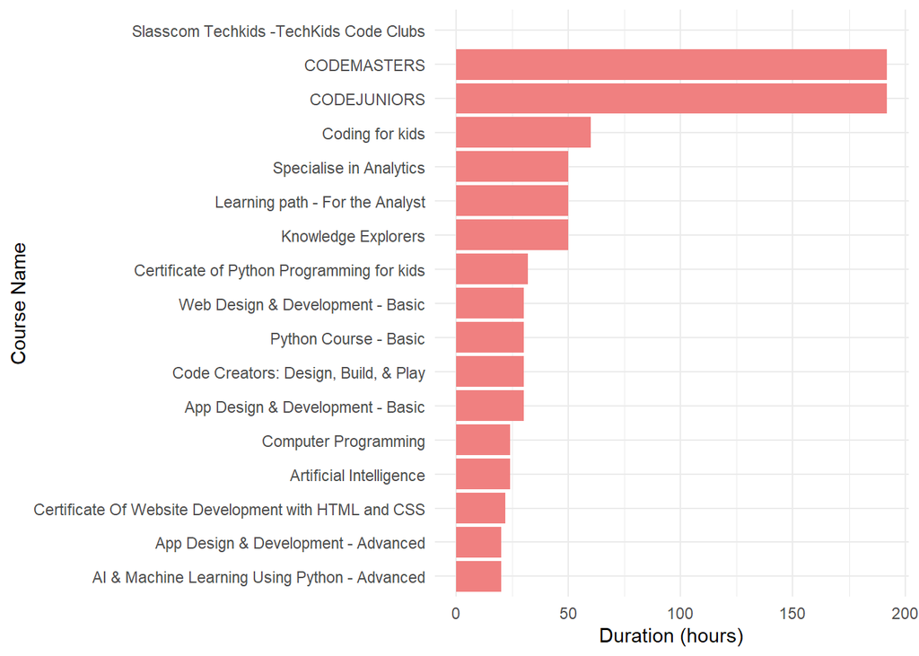

#### **Distribution of Course Duration**

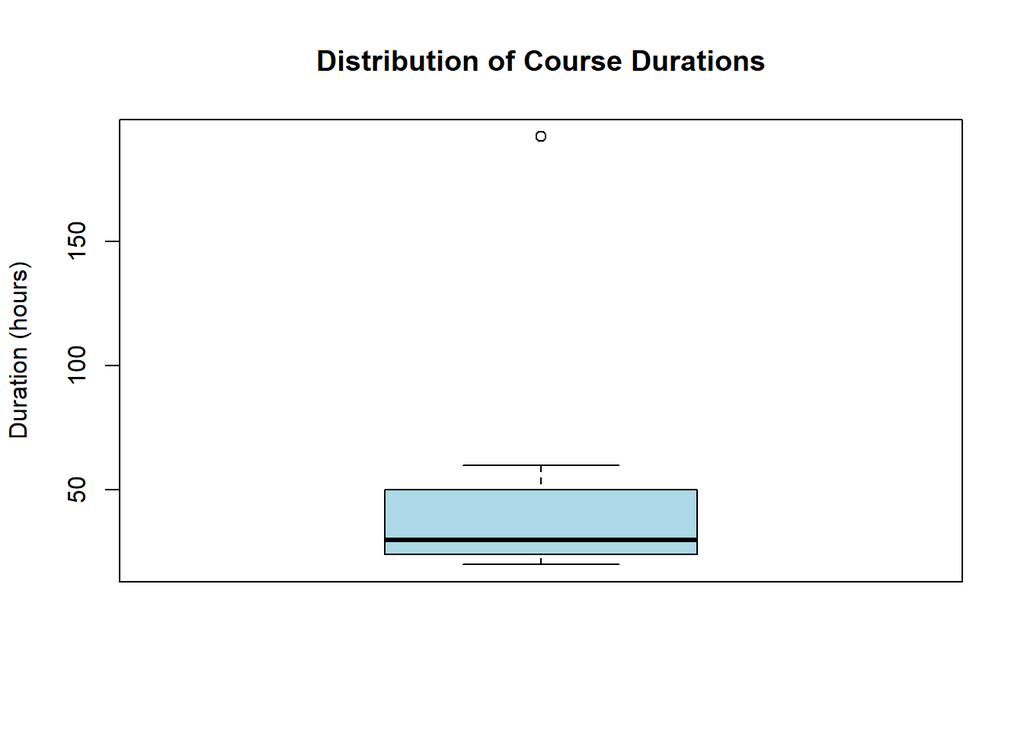

#### **Correlation between Duration and Course Fee**

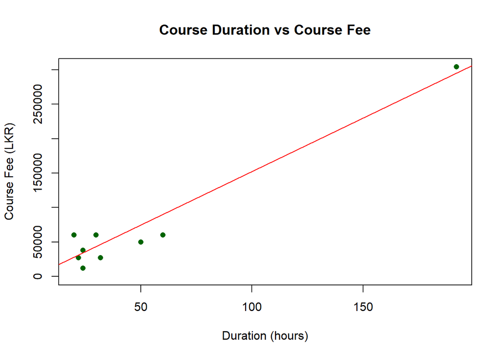

- There is a positive correlation between course duration and course fee, indicating that longer courses tend to be more expensive.

#### **Course Duration with Delivery methods**

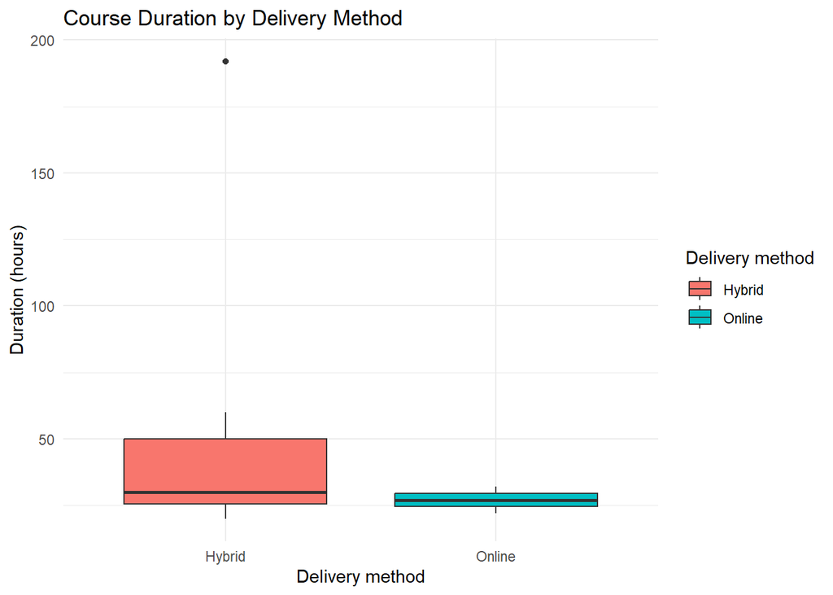

## 5. Delivery Methods

To compare the coding products with similar offerings in the market and identify unique selling points or gaps in the market

#### Distribution of Delivery Methods

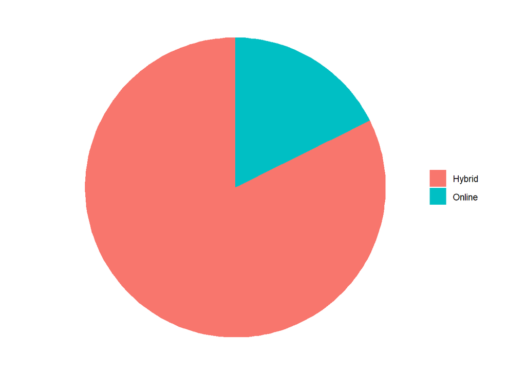

The pie chart shows that most coding courses are offered through hybrid methods, with only a few available online.

#### Average Fee by Delivery Method

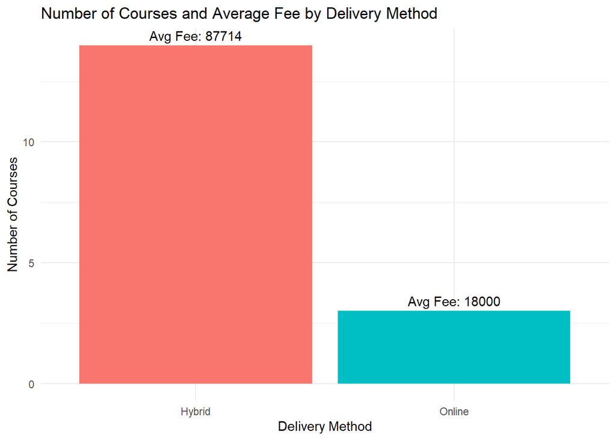

## 6.Market Positioning Insight

To compare the coding products with similar offerings in the market and identify unique selling points or gaps in the market

```
## # A tibble: 1 × 3
##   avg_duration avg_fee count_courses
##          <dbl>   <dbl>         <int>
## 1         53.5  75412.            17
```

#### The most common features

```
## # A tibble: 73 × 2
##    Features                    n
##    <chr>                   <int>
##  1 Python                      9
##  2 Scratch                     9
##  3 HTML/CSS                    8
##  4 JavaScript                  5
##  5 Machine Learning            4
##  6 AWS                         3
##  7 Arduino                     3
##  8 Artificial Intelligence     3
##  9 Azure                       3
## 10 C++                         3
## # ℹ 63 more rows
```

#### Unique Features

```
## # A tibble: 55 × 2
##    Features                    n
##    <chr>                   <int>
##  1 AI                          1
##  2 Academia                    1
##  3 Animation                   1
##  4 App Design                  1
##  5 App Inventor                1
##  6 Astronomy                   1
##  7 Basic Electronics           1
##  8 Bioinformatics              1
##  9 Build responsive Layout     1
## 10 CSS Transition              1
## # ℹ 45 more rows
```

On average, the coding courses have a duration of 53.5 hours and an average fee of 75,412 LKR. The most commonly taught features include Python, Scratch, and HTML/CSS, with Python and Scratch being the most prevalent in 9 courses each. Unique features identified across the courses include AI, App Design, Astronomy, and several others, indicating some courses offer specialized content not widely available.

## 7. Comparing with Hypothetical Competitor

Let’s assume for “Compatitor A” course , the Average course fee is Rs.50,000 and the Average coursze duration is 40 hours.

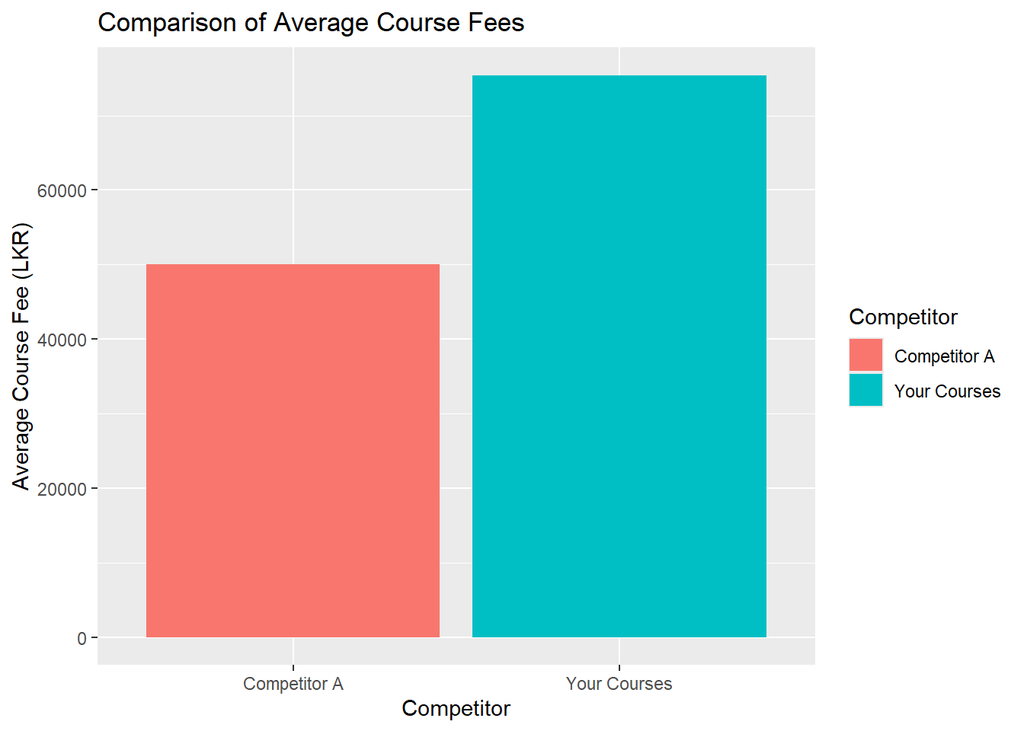

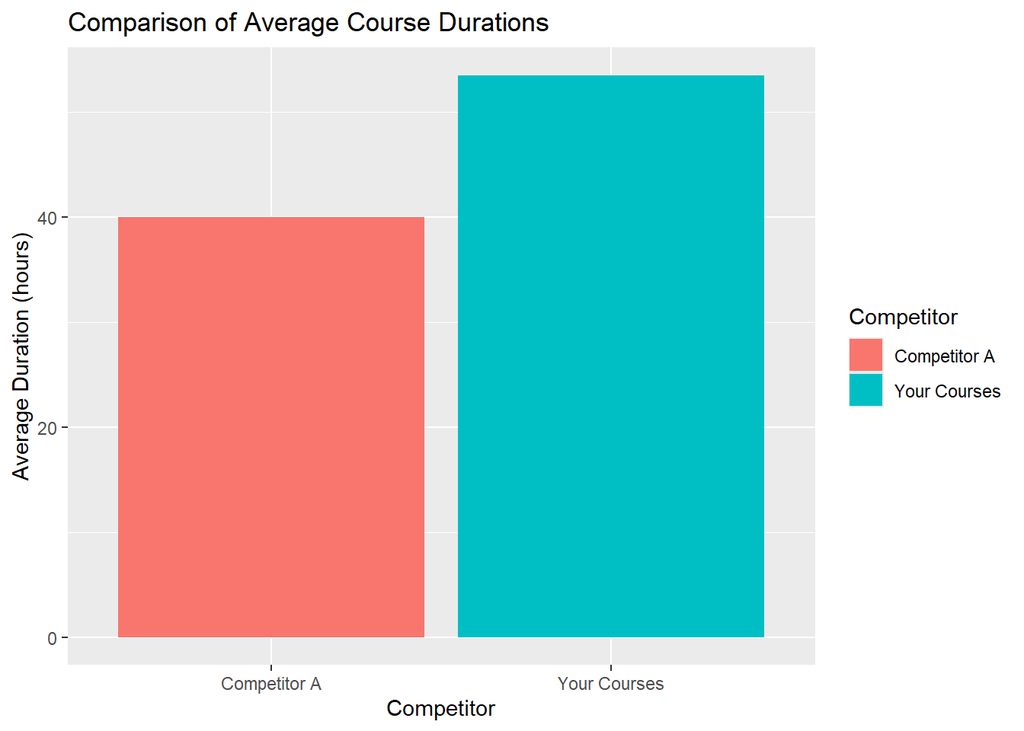

The plots I created show how these courses’ average fees and durations compare to those of Competitor A. This visual comparison helps highlight differences in pricing and course length between these offerings and those of a competitor.

## 8. Experiment Proposal: Comparing the Effectiveness of Our Coding Product vs. Competitor’s Product

The goal of this experiment is to determine whether our coding product or the competitor’s product is more effective in teaching coding skills to students.

### Experiment Design

#### 1. Participant Selection

Select 20 students from the same classroom. All students should be of the same age and have a similar level of prior coding knowledge to ensure a fair comparison.

#### 2. Initial Assessment

Before the learning phase, administer a coding test to all 20 students to assess their current coding skills. Record the test results for each student.

#### 3. Group Division

- Divide the students into two groups of 10 students each.
- **Group A** will use our coding product for learning.
- **Group B** will use the competitor’s coding product.

#### 4. Learning Phase

Provide both groups with sufficient time to learn coding using their respective products. Ensure that the learning conditions are the same for both groups (e.g., time spent learning, access to resources, etc.).

#### 5. Post-Learning Assessment

After the learning phase, administer the same coding test to both groups. Record the test results for each student again.

#### 6. Data Analysis

Compare the test results before and after the learning phase for both groups. Analyze the improvement in coding skills for each group to determine which product led to greater progress.

#### 7. Conclusion

The results will show whether our coding product or the competitor’s product is more effective in improving coding skills among students.

### Key Points for Explanation

- The experiment is designed to be fair, with both groups starting at the same level.
- The use of pre- and post-tests allows us to measure the exact improvement in skills.
- By comparing the results, we can make an informed decision about which product is better.